# Movie Report

Taikgun Song

October 9, 2018

# Nov 6th, 2018

### Variables in the dataset

- Total.Gross
- Production.Budget
- Studio
- MPAA. Rating
- Runtime
- rating
- director_tot
- writers_tot
- writers_max
- stars_tot
- stars_max
- stars_mean
- stars_sd
- stars_kurtosis

A new variable `sf_c` was created to categorize the success/failure of each movie. * s: success - (Total.Gross>2*Production.Budget)* f: Failure - (Total.Gross<Production.Budget) * e: Even - Otherwise

```
[1] "stars_kurtosis"
```

```
[1] "Genre"          "MPAA.Rating"    "writers_tot"    "writers_max"
[5] "writers_mean"   "stars_tot"      "stars_max"      "stars_mean"
[9] "stars_kurtosis"
```

```
[1] "Genre"          "MPAA.Rating"    "director_tot"   "writers_tot"
[5] "stars_tot"      "stars_mean"     "stars_kurtosis"
```

```
[1] "Genre"          "MPAA.Rating"    "director_tot"   "writers_max"
[5] "stars_tot"      "stars_mean"     "stars_kurtosis"
```

```
[1] "Genre"          "MPAA.Rating"    "director_tot"   "writers_mean"
[5] "stars_tot"      "stars_mean"     "stars_kurtosis"
```

```
[1] "Genre"        "director_tot" "writers_tot"  "writers_max"
[5] "stars_tot"    "stars_mean"
```

# Dataset

### Box Office Mojo Dataset

The box office dataset was scraped from the https://www.boxofficemojo.com website. The weekly box office chart provide box office information for each week (7-days, Friday through Thursday). The dataset consist of 98,482 with 20 variables. 8,389 unique movies from August 5-11, 2005 to September 7-13, 2018. Below is an example of the dataset.

A handful of movies in the initial dataset contains minor movies, and for this pilot study, a small subset of movies were selected based on the existence of the budget variable in the initial dataset. The subset consist of 1,723 number of movies (considered as movies opened nation wide).

[output not shown]

[output cut: 20 more lines]

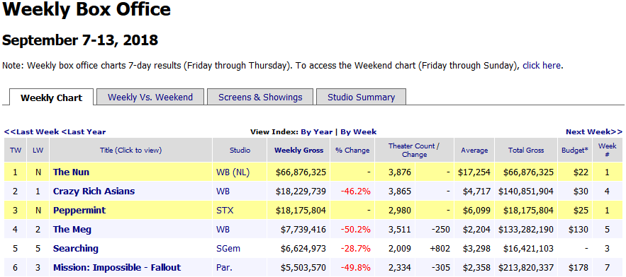

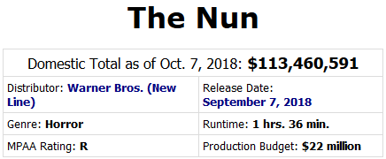

### IMDb Dataset

The Box Office Mojo does not provide information such as ratings, plot summary, director, writers, starts, *et cetera*. Therefore, further information were gathered from the IMDb webpage.

[output not shown]

[figure not shown]

Example of the individual movie information from the IMDb